# T-DEV-810 --- Groupe N°12

- Jonathan Khalifa
- Valentin Noel
- Fabrice Sumsa
- Bastien Angles
- Kevan Sadeghi

# Features :

- CLAHE
- ROC/AUC
- K-Fold cross validation
- Data augmentation
- Grad-Cam
- Architecture diagram

### Imports

```python
import glob
import imutils
import numpy as np
import pandas as pd
from PIL import Image, ImageOps
from sklearn.metrics import roc_auc_score
from sklearn.metrics import classification_report,confusion_matrix
import matplotlib.pyplot as plt
import seaborn as sns
import os
import random
import math
from tqdm.notebook import tqdm
import cv2
import itertools
from livelossplot import PlotLossesKeras
import keras
import visualkeras
import tensorflow as tf
from tensorflow import keras
from tensorflow.keras.utils import to_categorical
from tensorflow.keras.models import Sequential
from tensorflow.keras.callbacks import ModelCheckpoint, ReduceLROnPlateau, EarlyStopping
from tensorflow.keras.layers import Dense, Conv2D, MaxPool2D, Flatten,BatchNormalization, Dropout
from tensorflow.keras.preprocessing.image import ImageDataGenerator
import warnings
warnings.simplefilter(action='ignore', category=FutureWarning)
```

### Global vars

- Common batch size values : 16 - 32 - 64 - 128
- Epochs to determine the duration of our model training
- Train size sample for the total amount of equally distributed images before data augmentation.
- Max train sample size is 4023. max val to have equally distributed image categories.
- Image size(width, height). according to this studdy https://pubs.rsna.org/doi/full/10.1148/ryai.2019190015 the optimal size is 256x256. But lacking enough calculation power, we will remain at 64x64 while still getting decent results.

```python
BATCH_SIZE = 8
EPOCHS = 100
TRAIN_SAMPLE_SIZE = 4023
IMG_SIZE = 64
PATH_SAVE_MODEL = "SAVED_MODELS/T-DEV-810/training6/cp.ckpt"

PATH_VAL_PNEU = "/Users/jk/Downloads/chest_Xray/val/PNEUMONIA/*"
PATH_VAL_NORM = "/Users/jk/Downloads/chest_Xray/val/NORMAL/*"
PATH_TRAIN_VIR = "/Users/jk/Downloads/chest_Xray/train/PNEUMONIA/*virus*.*"
PATH_TRAIN_BACT = "/Users/jk/Downloads/chest_Xray/train/PNEUMONIA/*bacteria*.*"
PATH_TRAIN_NORM = "/Users/jk/Downloads/chest_Xray/train/NORMAL/*"
PATH_TEST_NORM = "/Users/jk/Downloads/chest_Xray/test/NORMAL/*"
PATH_TEST_VIR = "/Users/jk/Downloads/chest_Xray/test/PNEUMONIA/*virus*.*"
PATH_TEST_BACT = "/Users/jk/Downloads/chest_Xray/test/PNEUMONIA/*bacteria*.*"

PATH_EXAMPLE_IMAGE1 = "/Users/jk/Downloads/chest_Xray/val/PNEUMONIA/person1954_bacteria_4886.jpeg"
PATH_EXAMPLE_IMAGE2 = "/Users/jk/Downloads/chest_Xray/val/NORMAL/NORMAL2-IM-1442-0001.jpeg"
PATH_EXAMPLE_IMAGE3 = "/Users/jk/Downloads/chest_Xray/train/PNEUMONIA/person995_virus_1676.jpeg"
```

### Load the Dataset

- We plot the distribution of our image's labels to see the disparities.
- The plot reveals that we will need to redistribute the datasets for better training.

```
We have  1345  viral pneumonia train files
We have  1341  normal train files
We have  2530  bacterial pneumonia train files
We have  148  viral pneumonia test files
We have  234  normal test files
We have  242  bacterial pneumonia test files
We have  16  total validation files
```

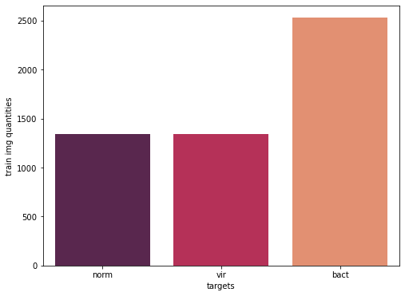

```python
# Load the training files
files_train_vir = glob.glob(PATH_TRAIN_VIR)
files_train_bact = glob.glob(PATH_TRAIN_BACT)
files_train_norm = glob.glob(PATH_TRAIN_NORM)
files_test_norm = glob.glob(PATH_TEST_NORM)
files_test_vir = glob.glob(PATH_TEST_VIR)
files_test_bact = glob.glob(PATH_TEST_BACT)
files_validate_pneu = glob.glob(PATH_VAL_PNEU)
files_validate_norm = glob.glob(PATH_VAL_NORM)
files_validate = (files_validate_norm + files_validate_pneu)

# shuffle
random.shuffle(files_train_vir)
random.shuffle(files_train_bact)
random.shuffle(files_train_norm)
random.shuffle(files_test_vir)
random.shuffle(files_test_bact)
random.shuffle(files_test_norm)
random.shuffle(files_validate)


print('We have ', len(files_train_vir) ,' viral pneumonia train files')
print('We have ', len(files_train_norm) ,' normal train files')
print('We have ', len(files_train_bact) ,' bacterial pneumonia train files')
print('We have ', len(files_test_vir) ,' viral pneumonia test files')
print('We have ', len(files_test_norm) ,' normal test files')
print('We have ', len(files_test_bact) ,' bacterial pneumonia test files')
print('We have ', len(files_validate) ,' total validation files')


# distrib plot
x = ('norm', 'vir', 'bact')
y = [len(files_train_norm),len(files_train_vir),len(files_train_bact)]


df2 = pd.DataFrame({'targets':x,
                    'train img quantities':y})
fig, ax = plt.subplots(figsize=(8,6))
sns.barplot(x = 'targets',
            y = 'train img quantities',
            data = df2,
            ax=ax,
            palette = "rocket")

plt.show()
```

### We make a new training batch with equaly distributed image categories.

```
Total images in sample equally distributed dataset :  4023
```

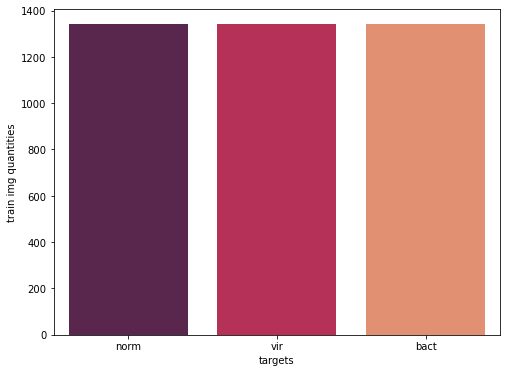

```python
train_subsample_size = int(TRAIN_SAMPLE_SIZE/3)
files_train_n = files_train_norm[:train_subsample_size]
files_train_v = files_train_vir[:train_subsample_size]
files_train_b = files_train_bact[:train_subsample_size]

t = min([len(files_test_bact),len(files_test_norm),len(files_test_vir)])
files_test_n = files_test_norm[:t]
files_test_v = files_test_vir[:t]
files_test_b = files_test_bact[:t]

# distrib plot
x = ('norm', 'vir', 'bact')
y = [len(files_train_n),
     len(files_train_v),
     len(files_train_b)]

print('Total images in sample equally distributed dataset : ', len(files_train_n)+
     len(files_train_v)+
     len(files_train_b))

df2 = pd.DataFrame({'targets':x,
                    'train img quantities':y})
fig, ax = plt.subplots(figsize=(8,6))
sns.barplot(x = 'targets',
            y = 'train img quantities',
            data = df2,
            ax=ax,
            palette = "rocket")
plt.show()
```

### Scatter plot for image dimensions distribution will help us see if we need to reshape our images or not.

- notice that nearly all of our images have different sizes. We will need to resize them all.

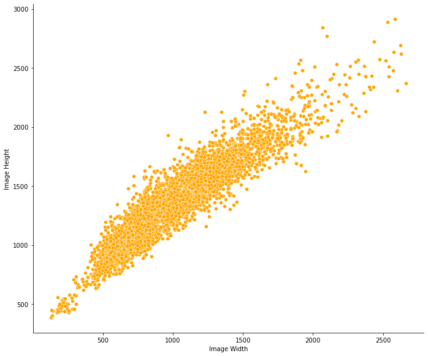

```python
files_train_sp = files_train_norm[:train_subsample_size] + files_train_vir[:train_subsample_size] + files_train_bact[:train_subsample_size]

xscatter = []
yscatter = []
for a in files_train_sp:
    img = cv2.imread(a)
    height, width, channels = img.shape
    xscatter.append(height)
    yscatter.append(width)


df = pd.DataFrame({'Image Width':xscatter,
                   'Image Height':yscatter})

sns.relplot(data=df,
            x='Image Width',
            y='Image Height',
            kind='scatter',
            height=8,
            aspect=1.2,
            color='orange')
```

### A bit of research before preparing our data

#### We have tested two options as for image pimping. examples below :

- We either apply CLAHE algorithm on our images in order to enhance contrasts eqalization.
- Or we apply segmentation to our images in order to saturate contrasts on our image's lungs #### In the end we will keep CLAHE for better results, but both examples of image preprocessing remains below

```
 Example of image enhancement with Segmentation
```

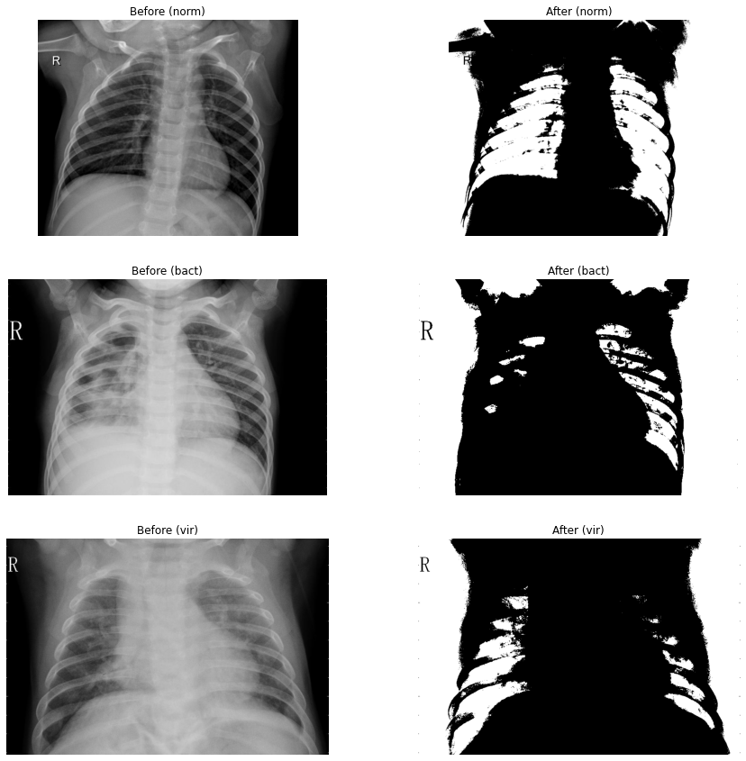

```
 Example of image enhancement with CLAHE
```

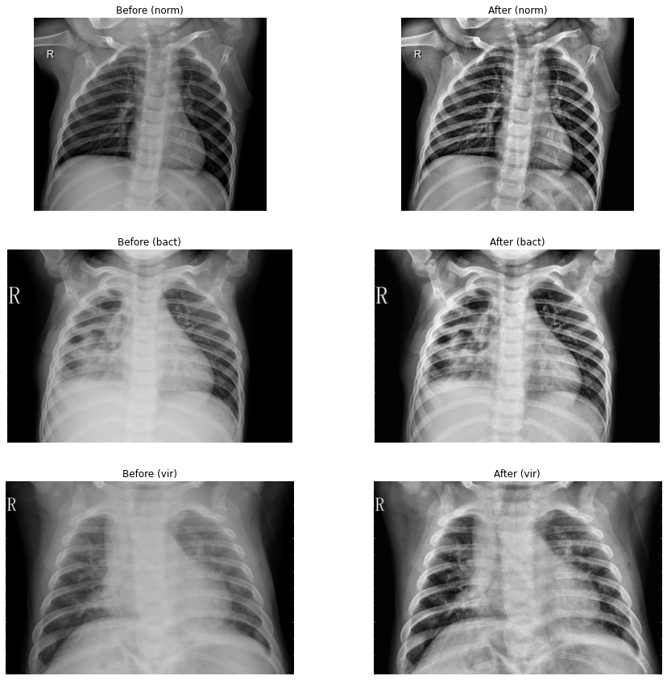

```python
#random image as for example
bgr = cv2.imread(PATH_EXAMPLE_IMAGE2,0)
bgr2 = cv2.imread(PATH_EXAMPLE_IMAGE1,0)
bgr3 = cv2.imread(PATH_EXAMPLE_IMAGE3,0)
bgr4 = cv2.imread(PATH_EXAMPLE_IMAGE2,0)
bgr5 = cv2.imread(PATH_EXAMPLE_IMAGE1,0)
bgr6 = cv2.imread(PATH_EXAMPLE_IMAGE3,0)


# SEMGENTATION
ret, cl = cv2.threshold(bgr,0,255,cv2.THRESH_BINARY_INV+cv2.THRESH_OTSU)
ret, cl2 = cv2.threshold(bgr2,0,255,cv2.THRESH_BINARY_INV+cv2.THRESH_OTSU)
ret, cl3 = cv2.threshold(bgr3,0,255,cv2.THRESH_BINARY_INV+cv2.THRESH_OTSU)
cl = cv2.cvtColor(cl,cv2.COLOR_GRAY2BGR)
cl2 = cv2.cvtColor(cl2,cv2.COLOR_GRAY2BGR)
cl3 = cv2.cvtColor(cl3,cv2.COLOR_GRAY2BGR)
bgr3 = cv2.cvtColor(bgr3, cv2.COLOR_BGR2RGB)
bgr2 = cv2.cvtColor(bgr2, cv2.COLOR_BGR2RGB)
bgr = cv2.cvtColor(bgr, cv2.COLOR_BGR2RGB)


print(" Example of image enhancement with Segmentation ")


# plotting the results
plt.figure(figsize=(15,15))
plt.subplot(321)
plt.axis('off')
plt.imshow(bgr)
plt.title("Before (norm)")
plt.subplot(322)
plt.axis('off')
plt.imshow(cl)
plt.title("After (norm)")
plt.subplot(323)
plt.axis('off')
plt.imshow(bgr2)
plt.title("Before (bact)")
plt.subplot(324)
plt.axis('off')
plt.imshow(cl2)
plt.title("After (bact)")
plt.subplot(325)
plt.axis('off')
plt.imshow(bgr3)
plt.title("Before (vir)")
plt.subplot(326)
plt.axis('off')
plt.imshow(cl3)
plt.title("After (vir)")
plt.show()


#CLAHE
clahe = cv2.createCLAHE(clipLimit=2.0, tileGridSize=(8,8))
cl4 = clahe.apply(bgr4)
cl5 = clahe.apply(bgr5)
cl6 = clahe.apply(bgr6)
cl6 = cv2.cvtColor(cl6, cv2.COLOR_BGR2RGB)
cl5 = cv2.cvtColor(cl5, cv2.COLOR_BGR2RGB)
cl4 = cv2.cvtColor(cl4, cv2.COLOR_BGR2RGB)
bgr6 = cv2.cvtColor(bgr6, cv2.COLOR_BGR2RGB)
bgr5 = cv2.cvtColor(bgr5, cv2.COLOR_BGR2RGB)
bgr4 = cv2.cvtColor(bgr4, cv2.COLOR_BGR2RGB)


print(" Example of image enhancement with CLAHE ")


# plotting the results
plt.figure(figsize=(15,15))
plt.subplot(321)
plt.axis('off')
plt.imshow(bgr4)
plt.title("Before (norm)")
plt.subplot(322)
plt.axis('off')
plt.imshow(cl4)
plt.title("After (norm)")
plt.subplot(323)
plt.axis('off')
plt.imshow(bgr5)
plt.title("Before (bact)")
plt.subplot(324)
plt.axis('off')
plt.imshow(cl5)
plt.title("After (bact)")
plt.subplot(325)
plt.axis('off')
plt.imshow(bgr6)
plt.title("Before (vir)")
plt.subplot(326)
plt.axis('off')
plt.imshow(cl6)
plt.title("After (vir)")
plt.show()
```

### Preparing the different data blocs for k-fold cross validation

- Since we have a small dataset of images we will only use k=3

```python
# equal nb of images per target
train_subsample_size = int(TRAIN_SAMPLE_SIZE/3)
files_train_n = files_train_norm[:train_subsample_size]
files_train_v = files_train_vir[:train_subsample_size]
files_train_b = files_train_bact[:train_subsample_size]


# equal nb of images per target
t = min([len(files_test_bact),len(files_test_norm),len(files_test_vir)])
files_test_n = files_test_norm[:t]
files_test_v = files_test_vir[:t]
files_test_b = files_test_bact[:t]


# concat old train and test and split in 3 of each target
merge_n = (files_train_n + files_test_n)
merge_n_bloc1, merge_n_bloc2, merge_n_bloc3 = np.array_split(merge_n,3);

merge_v = (files_train_v + files_test_v)
merge_v_bloc1, merge_v_bloc2, merge_v_bloc3 = np.array_split(merge_v,3);

merge_b = (files_train_b + files_test_b)
merge_b_bloc1, merge_b_bloc2, merge_b_bloc3 = np.array_split(merge_b,3);


# concat one block of each target in order to have 3 same size final blocks with equal nb of targets
bloc1 = np.concatenate([merge_n_bloc1,merge_v_bloc1,merge_b_bloc1])
random.shuffle(bloc1)

bloc2 = np.concatenate([merge_n_bloc2,merge_v_bloc2,merge_b_bloc2])
random.shuffle(bloc2)

bloc3 = np.concatenate([merge_n_bloc3,merge_v_bloc3,merge_b_bloc3])
random.shuffle(bloc3)


print("Each bloc has equally distributed nb of targets and each bloc has a similar size")
print("bloc1 length            : ",len(bloc1))
print("bloc2 length            : ",len(bloc2))
print("bloc3 length            : ",len(bloc3))
```

```
Each bloc has equally distributed nb of targets and each bloc has a similar size
bloc1 length            :  1491
bloc2 length            :  1488
bloc3 length            :  1488
```

### Time to fix our datasets

#### For this data to be usefull, we will have to do the following :

- create the labels
- put all the images to the same size
- put all the images to RGB (3 channels)
- enhance our contrasts with CLAHE (Contrast-Limited Adaptive Histogram Equalization)

```python
# label , resize and RGB
def fixData(dataset):
    #random.shuffle(dataset)
    clahe = cv2.createCLAHE(clipLimit=2.0, tileGridSize=(8,8))
    y_data = []
    x_data = []
    for file in dataset:
        image = cv2.imread(file)
        image = cv2.cvtColor(np.array(image), cv2.COLOR_BGR2GRAY)
        image = clahe.apply(image)
        image = cv2.cvtColor(image,cv2.COLOR_GRAY2RGB)
        image = cv2.resize(image, (IMG_SIZE, IMG_SIZE))

        data = np.array(image)

        x_data.append(data)

        # LABELS
        if("virus" in file):
            target = 1
        elif("bacteria" in file):
            target = 2
        else:
            target = 0

        y_data.append(target)
    x_data = np.asarray(x_data)
    y_data = np.asarray(y_data)
    y_data = to_categorical(y_data,3) # <-- one hot encoding :)
    return (x_data,y_data)


# fixing each bloc of images
(x_validate, y_validate) = fixData(files_validate)
(x_bloc1, y_bloc1) = fixData(bloc1)
(x_bloc2, y_bloc2) = fixData(bloc2)
(x_bloc3, y_bloc3) = fixData(bloc3)



# Normalize data
def normData(data):
    xmax = data.max()
    data = data / xmax
    return data



# stats to be printed
print("Features bloc1 shape               : ", x_bloc1.shape)
print("Targets bloc1 shape                : ", y_bloc1.shape)
print('Bloc 1 Before normalization        : min={}, max={}'.format(x_bloc1.min(), x_bloc1.max()))
x_bloc1 = normData(x_bloc1)
print('Bloc 1 After normalisation         : min={}, max={}'.format(x_bloc1.min(), x_bloc1.max()))
print("------------------------------------")

print("Features bloc2 shape               : ", x_bloc2.shape)
print("Targets bloc2 shape                : ", y_bloc2.shape)
print('Bloc 2 Before normalization        : min={}, max={}'.format(x_bloc2.min(), x_bloc2.max()))
x_bloc2 = normData(x_bloc2)
print('Bloc 2 After normalisation         : min={}, max={}'.format(x_bloc2.min(), x_bloc2.max()))
print("------------------------------------")

print("Features bloc3 shape               : ", x_bloc3.shape)
print("Targets bloc3 shape                : ", y_bloc3.shape)
print('Bloc 3 Before normalization        : min={}, max={}'.format(x_bloc3.min(), x_bloc3.max()))
x_bloc3 = normData(x_bloc3)
print('Bloc 3 After normalisation         : min={}, max={}'.format(x_bloc3.min(), x_bloc3.max()))
```

```
Features bloc1 shape               :  (1491, 64, 64, 3)
Targets bloc1 shape                :  (1491, 3)
Bloc 1 Before normalization        : min=0, max=255
Bloc 1 After normalisation         : min=0.0, max=1.0
------------------------------------
Features bloc2 shape               :  (1488, 64, 64, 3)
Targets bloc2 shape                :  (1488, 3)
Bloc 2 Before normalization        : min=0, max=255
Bloc 2 After normalisation         : min=0.0, max=1.0
------------------------------------
Features bloc3 shape               :  (1488, 64, 64, 3)
Targets bloc3 shape                :  (1488, 3)
Bloc 3 Before normalization        : min=0, max=255
Bloc 3 After normalisation         : min=0.0, max=1.0
```

### Check the Data

-Here we will display a small sample of our clean dataset allong with it's labels

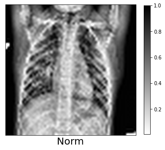

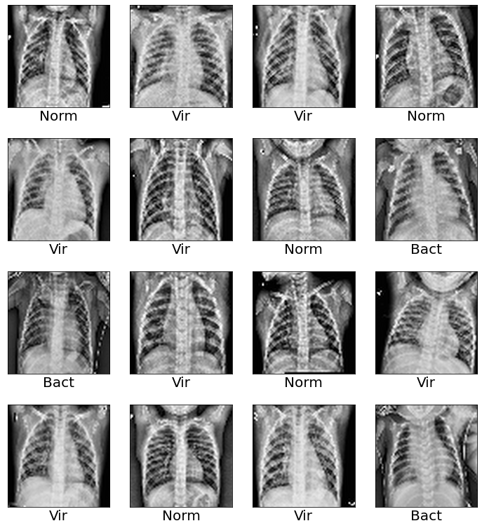

```python
# Targets names for plotting
def targetNames(targets):
    target_names = []
    for target in targets:
        if(target[0] > 0):
            target_names.append("Norm")
        elif(target[1] > 0):
            target_names.append("Vir")
        elif(target[2] > 0):
            target_names.append("Bact")
    return target_names



# Show some images in a grid, with legends
def plot_images(x,y=None, indices='all', columns=12, x_size=1, y_size=1,
                colorbar=False, y_pred=None, cm='binary', norm=None, y_padding=0.35, spines_alpha=1,
                fontsize=20, interpolation='lanczos', save_as='auto'):
    """
    args:
        x             : images - Shapes must be (-1,lx,ly) (-1,lx,ly,1) or (-1,lx,ly,3)
        y             : real classes or labels or None (None)
        indices       : indices of images to show or 'all' for all ('all')
        columns       : number of columns (12)
        x_size,y_size : figure size (1), (1)
        colorbar      : show colorbar (False)
        y_pred        : predicted classes (None)
        cm            : Matplotlib color map (binary)
        norm          : Matplotlib imshow normalization (None)
        y_padding     : Padding / rows (0.35)
        spines_alpha  : Spines alpha (1.)
        font_size     : Font size in px (20)
        save_as       : Filename to use if save figs is enable ('auto')
    """
    if indices=='all': indices=range(len(x))
    if norm and len(norm) == 2: norm = matplotlib.colors.Normalize(vmin=norm[0], vmax=norm[1])
    draw_labels = (y is not None)
    draw_pred   = (y_pred is not None)
    rows        = math.ceil(len(indices)/columns)
    fig=plt.figure(figsize=(columns*x_size, rows*(y_size+y_padding)))
    n=1
    for i in indices:
        axs=fig.add_subplot(rows, columns, n)
        n+=1
        # ---- Shape is (lx,ly)
        if len(x[i].shape)==2:
            xx=x[i]
        # ---- Shape is (lx,ly,n)
        if len(x[i].shape)==3:
            (lx,ly,lz)=x[i].shape
            if lz==1:
                xx=x[i].reshape(lx,ly)
            else:
                xx=x[i]
        img=axs.imshow(xx,   cmap = cm, norm=norm, interpolation=interpolation)
        axs.spines['right'].set_visible(True)
        axs.spines['left'].set_visible(True)
        axs.spines['top'].set_visible(True)
        axs.spines['bottom'].set_visible(True)
        axs.spines['right'].set_alpha(spines_alpha)
        axs.spines['left'].set_alpha(spines_alpha)
        axs.spines['top'].set_alpha(spines_alpha)
        axs.spines['bottom'].set_alpha(spines_alpha)
        axs.set_yticks([])
        axs.set_xticks([])
        if draw_labels and not draw_pred:
            axs.set_xlabel(y[i],fontsize=fontsize)
        if draw_labels and draw_pred:
            if y[i]!=y_pred[i]:
                axs.set_xlabel(f'{y_pred[i]} ({y[i]})',fontsize=fontsize)
                axs.xaxis.label.set_color('red')
            else:
                axs.set_xlabel(y[i],fontsize=fontsize)
        if colorbar:
            fig.colorbar(img,orientation="vertical", shrink=0.65)
    plt.show()


y_names = targetNames(y_bloc1)
plot_images(x_bloc1, y_names, [0], x_size=7, y_size=7, colorbar=True)
plot_images(x_bloc1, y_names, range(0,16),x_size=3, y_size=3, columns=4)
```

### Data Augmentation

#### In order to avoid overfitting problem, we need to expand artificially our dataset. The idea is to alter the training data with small transformations to reproduce the variations. Approaches that alter the training data in ways that change the array representation while keeping the label the same.

```python
datagen = ImageDataGenerator(
        featurewise_center=False,             # set input mean to 0 over the dataset
        samplewise_center=False,              # set each sample mean to 0
        featurewise_std_normalization=False,  # divide inputs by std of the dataset
        samplewise_std_normalization=False,   # divide each input by its std
        zca_whitening=False,                  # apply ZCA whitening
        rotation_range = 10,                  # randomly rotate images in the range (degrees, 0 to 180)
        zoom_range = 0.2,                     # Randomly zoom image
        width_shift_range=0.1,                # randomly shift images horizontally (fraction of total width)
        height_shift_range=0.1,               # randomly shift images vertically (fraction of total height)
        horizontal_flip = True,               # randomly flip images
        vertical_flip=False)                  # randomly flip images
```

### The Model

#### We will use a convolutional neural network in order to classify our images

#### Specs :

- 3 convo layers with increasing amount of filters.
- large initial kernell size for catching larger details, then smaller kernells for catching small details
- activation function remains RELU accross the board exept for a final softmax in order to deal with our target probabilities.
- 3 max pooling layers with a grid size of 2x2
- 1 dropout that will disactivate 50% of the neurons
- ~We will use Nadam optimizer in order to benefit of momentum.~
- We will use Adam as optimizer #### Metrics :
- accuracy
- auc

```
Model: "sequential_11"
_________________________________________________________________
Layer (type)                 Output Shape              Param #
=================================================================
conv2d_22 (Conv2D)           (None, 61, 61, 32)        1568
_________________________________________________________________
max_pooling2d_22 (MaxPooling (None, 30, 30, 32)        0
_________________________________________________________________
spacing_dummy_layer_30 (Spac (None, 30, 30, 32)        0
_________________________________________________________________
conv2d_23 (Conv2D)           (None, 29, 29, 64)        8256
_________________________________________________________________
max_pooling2d_23 (MaxPooling (None, 14, 14, 64)        0
_________________________________________________________________
spacing_dummy_layer_31 (Spac (None, 14, 14, 64)        0
_________________________________________________________________
lastConv (Conv2D)            (None, 13, 13, 128)       32896
_________________________________________________________________
1 (MaxPooling2D)             (None, 6, 6, 128)         0
_________________________________________________________________
spacing_dummy_layer_32 (Spac (None, 6, 6, 128)         0
_________________________________________________________________
2 (Dropout)                  (None, 6, 6, 128)         0
_________________________________________________________________
3 (Flatten)                  (None, 4608)              0
_________________________________________________________________
spacing_dummy_layer_33 (Spac (None, 4608)              0
_________________________________________________________________
4 (Dense)                    (None, 1024)              4719616
_________________________________________________________________
7 (Dense)                    (None, 3)                 3075
=================================================================
Total params: 4,765,411
Trainable params: 4,765,411
Non-trainable params: 0
_________________________________________________________________
Model architecture diagram :
```

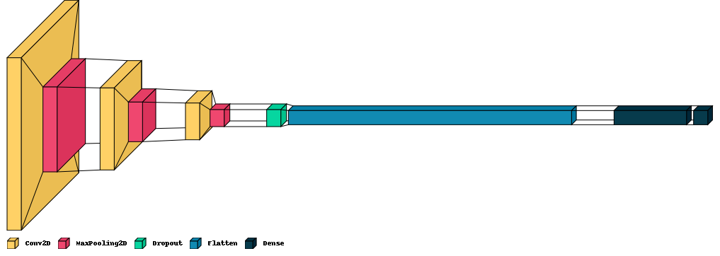

```python
def create_model():
    model = keras.models.Sequential()

    model.add(Conv2D(filters=32, kernel_size=(4,4), input_shape=(IMG_SIZE,IMG_SIZE,3), activation='relu',))
    model.add(MaxPool2D(pool_size=(2,2)))
    model.add(visualkeras.SpacingDummyLayer())

    model.add(Conv2D(filters=64, kernel_size=(2,2), activation='relu',))
    model.add(MaxPool2D(pool_size=(2,2)))
    model.add(visualkeras.SpacingDummyLayer())

    model.add(Conv2D(filters=128,name='lastConv', kernel_size=(2,2), activation='relu',))
    model.add(MaxPool2D(pool_size=(2,2),name='1'))
    model.add(visualkeras.SpacingDummyLayer())

    model.add(Dropout(0.5,name='2'))
    model.add(Flatten(name='3'))
    model.add(visualkeras.SpacingDummyLayer())

    model.add(Dense(1024, activation='relu',name='4'))
    model.add(Dense(3,name='7', activation='softmax'))

    #optimizers
    opt = keras.optimizers.Adam(learning_rate=0.0002)

    model.compile(optimizer=opt,
                  loss='categorical_crossentropy',
                 metrics=[tf.keras.metrics.AUC(),'accuracy'])
    return model


# Create a basic model instance
model = create_model()
model.summary()
print("Model architecture diagram :")
visualkeras.layered_view(model,legend=True)
```

## Train the model

- learning rate is a hyperparameter that controls how much to change the model in response to the estimated error each time the model weights are updated
- Best learning rate for Adam opti : 3e-4 according to google but for our model it differs a bit.
- We will dynamically plot each epoch as the model trains.
- The model will stop training if 15 consecutive epochs overfit.
- We save the model's weights for later re-use.
- We have a ladder learning rate decay that triggers whenever we have 4 consecutive epochs that overfit.

#### training will be done in 3 steps for cross validation :

- step 1 : train = bloc1 + bloc2 , test = bloc 3
- step 2 : train = bloc2 + bloc3 , test = bloc 1
- step 3 : train = bloc1 + bloc3 , test = bloc 2

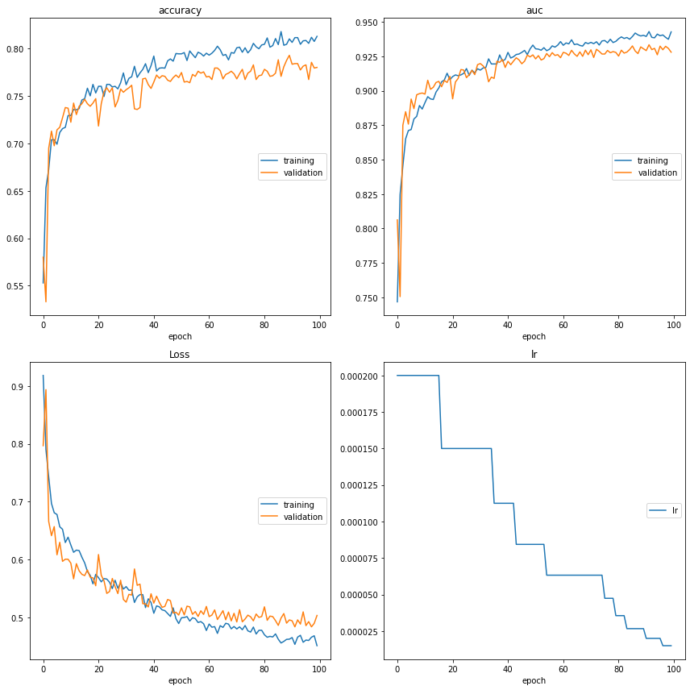

```
accuracy
	training         	 (min:    0.553, max:    0.818, cur:    0.813)
	validation       	 (min:    0.533, max:    0.793, cur:    0.780)
auc
	training         	 (min:    0.747, max:    0.943, cur:    0.943)
	validation       	 (min:    0.751, max:    0.933, cur:    0.928)
Loss
	training         	 (min:    0.451, max:    0.918, cur:    0.451)
	validation       	 (min:    0.484, max:    0.894, cur:    0.503)
lr
	lr               	 (min:    0.000, max:    0.000, cur:    0.000)
['loss', 'auc', 'accuracy']
[(0.48443037271499634, 0.93672114610672, 0.8071236610412598), (0.5010800361633301, 0.931718111038208, 0.7786720395088196), (0.5289214849472046, 0.9286917448043823, 0.7836021780967712)]
```

```python
scores = []
index = [0,1,2]
for i in index:
    if i == 0:
        tf.keras.backend.clear_session()
        x_train = (x_bloc1, x_bloc2)
        x_train = np.vstack(x_train)
        y_train = (y_bloc1, y_bloc2)
        y_train = np.vstack(y_train)
        x_test = x_bloc3
        y_test = y_bloc3
    if i == 1:
        tf.keras.backend.clear_session()
        x_train = (x_bloc2, x_bloc3)
        x_train = np.vstack(x_train)
        y_train = (y_bloc2, y_bloc3)
        y_train = np.vstack(y_train)
        x_test = x_bloc1
        y_test = y_bloc1
    if i == 2:
        tf.keras.backend.clear_session()
        x_train = (x_bloc1, x_bloc3)
        x_train = np.vstack(x_train)
        y_train = (y_bloc1, y_bloc3)
        y_train = np.vstack(y_train)
        x_test = x_bloc2
        y_test = y_bloc2

    # aug data
    datagen.fit(x_train)

    model = create_model()

    # Save weights for later re-use
    PATH_SAVE_MODEL = "SAVED_MODELS/T-DEV-810/trainingSplitFinal2"+str(index)+"/cp.ckpt"

    # directory to save model's weights
    checkpoint_dir = os.path.dirname(PATH_SAVE_MODEL)

    # Create a callback that saves the model's weights
    cp_callback = keras.callbacks.ModelCheckpoint(filepath=PATH_SAVE_MODEL,
                                                  save_weights_only=True,
                                                  verbose=1)

    # Create a callback to stop the model if overfits
    early_stop = EarlyStopping(monitor='val_loss',patience=15)
    lr_reduce = ReduceLROnPlateau(monitor='val_loss',
                                  factor=0.75,
                                  patience=4,
                                  verbose=2,
                                  mode='auto')


    # launch training
    history_split1 = model.fit(datagen.flow(x_train,y_train,batch_size = 8),
                        epochs = 100,
                        validation_data = datagen.flow(x_test, y_test),
                        callbacks = [early_stop,
                                     lr_reduce,
                                     cp_callback,
                                     PlotLossesKeras()])

    b = model.evaluate(x_test,y_test,verbose=0)
    #np.vstack((scores, b))
    scores.append(tuple(b))

# EVAL
model.metrics_names
print(model.metrics_names)
print(scores)
```

### Performance interpretation

- In order to have a better visual representation of our models performances, we'll print a classification report
- Then we'll see how our errors are distributed on a confusion matrix #### metrics :
- Accuracy : % d’exactitude de prediction. Good metric if equal distributed targets
- Recall : good for not equally distributed targets ( nbr of true positives / (nbr true pos + nbr false negs)
- Precision : good for not equally distributed targets (nbr of true positives / (nbr true pos + nbr false pos)
- F1 score : 2*( (precision* recall)/(precision + recall)) bon compromis entre precision et recall

```
              precision    recall  f1-score   support

        Bact       0.72      0.77      0.75       496
        Norm       0.85      0.99      0.92       496
         Vir       0.77      0.59      0.67       496

    accuracy                           0.78      1488
   macro avg       0.78      0.78      0.78      1488
weighted avg       0.78      0.78      0.78      1488
```

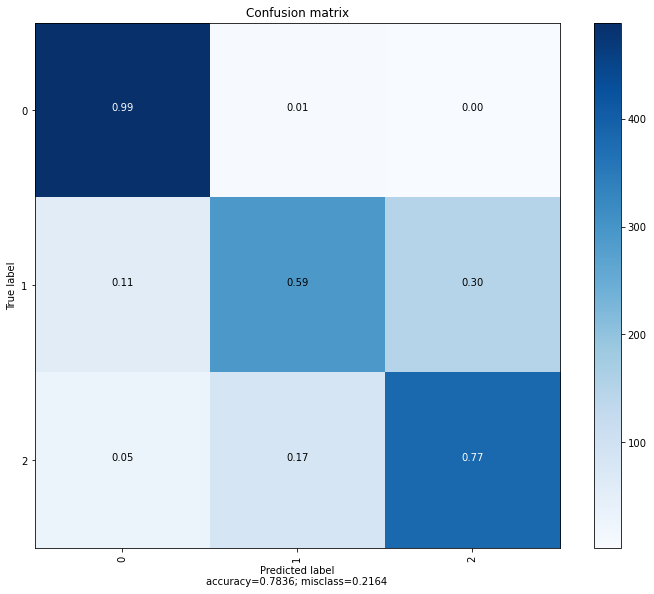

```python
# To plot the confusions matrix
def plot_confusion_matrix(y_true,y_pred,
                          target_names,
                          title='Confusion matrix',
                          cmap=None,
                          normalize=True,
                          figsize=(10, 8),
                          digit_format='{:0.2f}',
                          save_as='auto'):
    """
    cm:           confusion matrix from sklearn.metrics.confusion_matrix

    target_names: given classification classes such as [0, 1, 2]
                  the class names, for example: ['high', 'medium', 'low']

    title:        the text to display at the top of the matrix

    cmap:         the gradient of the values displayed from matplotlib.pyplot.cm
                  see http://matplotlib.org/examples/color/colormaps_reference.html
                  plt.get_cmap('jet') or plt.cm.Blues

    normalize:    If False, plot the raw numbers
                  If True, plot the proportions
    """
    cm = confusion_matrix( y_true,y_pred, normalize=None, labels=target_names)

    accuracy = np.trace(cm) / float(np.sum(cm))
    misclass = 1 - accuracy

    if cmap is None:
        cmap = plt.get_cmap('Blues')

    plt.figure(figsize=figsize)
    plt.imshow(cm, interpolation='nearest', cmap=cmap)
    plt.title(title)
    plt.colorbar()

    if target_names is not None:
        tick_marks = np.arange(len(target_names))
        plt.xticks(tick_marks, target_names, rotation=90)
        plt.yticks(tick_marks, target_names)

    if normalize:
        cm = cm.astype('float') / cm.sum(axis=1)[:, np.newaxis]


    thresh = cm.max() / 1.5 if normalize else cm.max() / 2
    for i, j in itertools.product(range(cm.shape[0]), range(cm.shape[1])):
        if normalize:
            plt.text(j, i, digit_format.format(cm[i, j]),
                     horizontalalignment="center",
                     color="white" if cm[i, j] > thresh else "black")
        else:
            plt.text(j, i, "{:,}".format(cm[i, j]),
                     horizontalalignment="center",
                     color="white" if cm[i, j] > thresh else "black")

    plt.tight_layout()
    plt.ylabel('True label')
    plt.xlabel('Predicted label\naccuracy={:0.4f}; misclass={:0.4f}'.format(accuracy, misclass))
    plt.show()


# single axis Targets names for plotting
def tgtNames(targets):
    target_names = []
    for target in targets:
        if(target == 0):
            target_names.append("Norm")
        elif(target == 1):
            target_names.append("Vir")
        elif(target == 2):
            target_names.append("Bact")
    return target_names


# put predictions and labels as single digit
predictions = np.argmax(model.predict(x_test), axis=1)
y_test_singleDigit = np.argmax(y_test, axis=1)
y_val_singleDigit = np.argmax(y_validate, axis=1)

y_test_names = tgtNames(y_test_singleDigit)
y_pred_names = tgtNames(predictions)
y_validate_names = tgtNames(y_val_singleDigit)

print(classification_report(y_test_names,y_pred_names))
plot_confusion_matrix(y_test_singleDigit,predictions, range(3), normalize=True)
```

##### GRADCAM

- Produces a heatmap of which regions of an image contributed strongly towards the final prediction
- The Grad-CAM output is an activation map which localises the detected objected to a region in the image

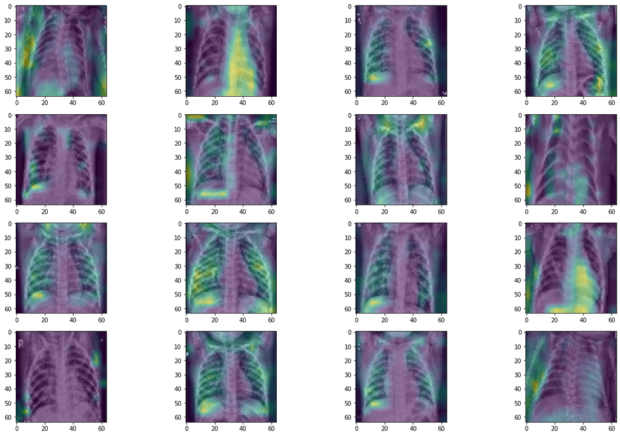

```python
nbRandImages = 16
imagesSample = random.sample(list(x_train), nbRandImages)
def gradCamSample(imagesSample):
    #We get the output of the last convolution layer. We then create a model that goes up to only that layer.
    last_conv_layer = model.get_layer("lastConv")
    last_conv_layer_model = tf.keras.Model(model.inputs, last_conv_layer.output)

    # We create a model which then takes the output of the model above, and uses the remaining layers to get the final predictions.
    classifier_input = tf.keras.Input(shape=last_conv_layer.output.shape[1:])
    x = classifier_input
    for layer_name in ["1","2","3","4"]:
        x = model.get_layer(layer_name)(x)
    classifier_model = tf.keras.Model(classifier_input, x)

    fig = plt.figure(figsize=(20,20))
    count = 1
    for image in imagesSample :
        with tf.GradientTape() as tape:
            inputs = image[np.newaxis, ...]
            last_conv_layer_output = last_conv_layer_model(inputs)
            tape.watch(last_conv_layer_output)
            preds = classifier_model(last_conv_layer_output)
            top_pred_index = tf.argmax(preds[0])
            top_class_channel = preds[:, top_pred_index]


        grads = tape.gradient(top_class_channel, last_conv_layer_output)
        pooled_grads = tf.reduce_mean(grads, axis=(0, 1, 2))

        last_conv_layer_output = last_conv_layer_output.numpy()[0]
        pooled_grads = pooled_grads.numpy()
        for i in range(pooled_grads.shape[-1]):
            last_conv_layer_output[:, :, i] *= pooled_grads[i]


        # Average over all the filters to get a single 2D array
        gradcam = np.mean(last_conv_layer_output, axis=-1)
        # Clip the values (equivalent to applying ReLU)
        # and then normalise the values
        gradcam = np.clip(gradcam, 0, np.max(gradcam)) / np.max(gradcam)
        gradcam = cv2.resize(gradcam, (IMG_SIZE, IMG_SIZE))

        axs=fig.add_subplot(6, 4, count)
        axs.imshow(image)
        axs.imshow(gradcam, alpha=0.5)
        count = count + 1
    count = 1

gradCamSample(imagesSample)
```

### Now let's see how our model predicts on a sample of images

- notice the erroneous predictions are labeled in red

```
image single digit label :  2
single digit label predicted by model :  [0]
```

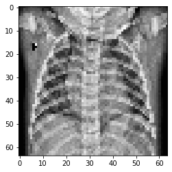

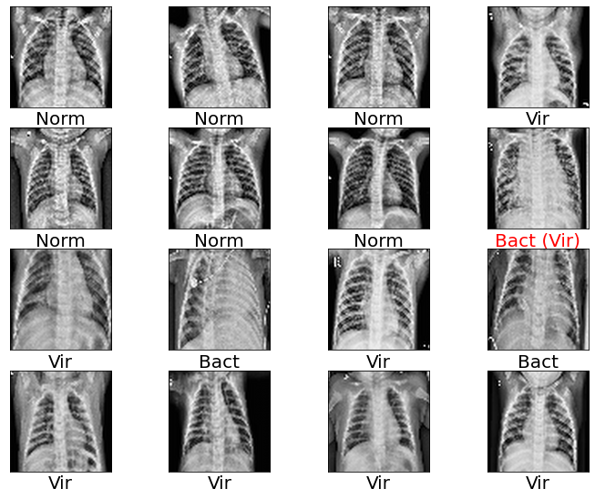

```python
my_image = x_test[2]
plt.imshow(my_image)
print('image single digit label : ', y_val_singleDigit[2])
pred = np.argmax(model.predict(my_image.reshape(1,IMG_SIZE,IMG_SIZE,3)), axis=1)
print('single digit label predicted by model : ', pred)

# prediction thumbnails sample
y_sigmoid = model.predict(x_test)
y_pred = np.argmax(y_sigmoid, axis=-1)
plot_images(x_test, y_test_names, range(100,116), columns=4, x_size=3, y_size=2, y_pred=y_pred_names)
```

### Here are a few images where our model has made a bad prediction

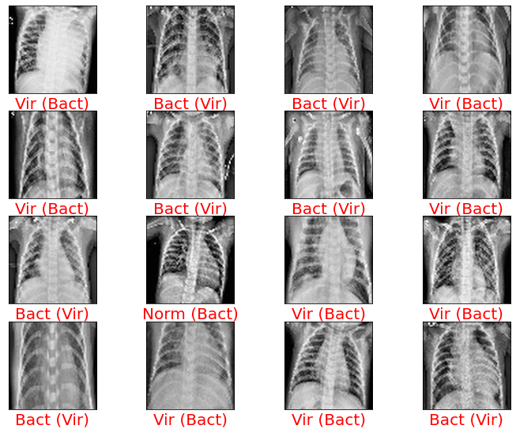

```python
# PLOT SOME ERRORS
errors=[ i for i in range(len(x_test)) if y_pred[i]!=y_test_singleDigit[i]]
errors = np.random.choice(errors,16)
#errors=errors[:min(15, len(errors))]
plot_images(x_test, y_test_names, errors[:16],
            columns=4, x_size=3, y_size=2, y_pred=y_pred_names)
```